# Lab4: Spatial correlation of your own dataset

Katarzyna Goch

22 Nov 2018

This is the report for the fourth assignment “Spatial correlation of your own dataset” from course “Analysis of Spatio-Temporal Data”, WS 2018/19.  
Supervisor: prof. Edzer Pebesma

## Import your own geostatistical dataset in R

Retail gas prices for reporting gas stations in Chicago on one day in April 2011 are shown. More information regarding the data can be found here: https://hub.arcgis.com/datasets/961f99c9cb254476989de907c1e0937d_0?geometry=-89.515%2C41.654%2C-86.902%2C42.012

```r
# Read in the shapefile
shapePKT <- readOGR(dsn="Chicago", layer="Chicago_April_05_Prices")
```

## Convert it into a spatial object (an object that knows what its spatial coordinates are)

Shapefile was read as a spatial object.

```r
# Lookup the data
summary(shapePKT)
```

```
## Object of class SpatialPointsDataFrame
## Coordinates:
##                 min       max
## coords.x1 -88.86482 -87.55254
## coords.x2  41.17192  42.48823
## Is projected: FALSE
## proj4string :
## [+proj=longlat +datum=WGS84 +no_defs +ellps=WGS84 +towgs84=0,0,0]
## Number of points: 1877
## Data attributes:
##       FID          OBJECTID                         Date_
##  1      :   1   10000  :   1   2011-04-05T00:00:00.000Z:1877
##  10     :   1   10001  :   1
##  100    :   1   10002  :   1
##  1000   :   1   10003  :   1
##  1001   :   1   10004  :   1
##  1002   :   1   10005  :   1
##  (Other):1871   (Other):1871
##  Time_Summa     Station_ID                    Station_Na
##  DAILY:1877   101692 :   1   BP                    : 102
##               103648 :   1   MACS CONVENIENCE STORE:  31
##               104378 :   1   SHELL                 :  20
##               104379 :   1   SHELL SERVICE STATION :  16
##               104382 :   1   MARATHON              :  13
##               104383 :   1   CITGO                 :   8
##               (Other):1871   (Other)               :1687
##                  Address              City      State        Zip_Code
##  1 E SAINT CHARLES RD:   2   Chicago    : 346   IL:1877   60618  :  19
##  20020 N RAND RD     :   2   Joliet     :  37             60525  :  17
##  4 W IRVING PARK RD  :   2   Aurora     :  36             60619  :  17
##  600 W NORTH AVE     :   2   Naperville :  31             60632  :  17
##  739 N STATE ST      :   2   Elgin      :  29             60101  :  16
##  1 ALEXANDER CIR     :   1   Des Plaines:  27             60123  :  16
##  (Other)             :1866   (Other)    :1371             (Other):1775
##        OPIS_Regio            MSA                County    Country
##  Great Lakes:1877   Chicago, Il:1877   IL - Cook   :988   USA:1877
##                                        IL - Du Page:257
##                                        IL - Lake   :198
##                                        IL - Will   :151
##                                        IL - Kane   :110
```

[output cut: 19 more lines]

```
##  Min.   :3.569   Min.   : 89.30   2011-04-06T00:00:00.000Z:1877
##  1st Qu.:3.899   1st Qu.: 97.56
##  Median :3.999   Median :100.06
##  Mean   :3.997   Mean   :100.00
##  3rd Qu.:4.099   3rd Qu.:102.56
##  Max.   :4.399   Max.   :110.06
##
##    Ave_LocalI
##  Min.   : 93.32
##  1st Qu.: 98.26
##  Median : 99.71
##  Mean   :100.02
##  3rd Qu.:101.67
##  Max.   :110.09
##
```

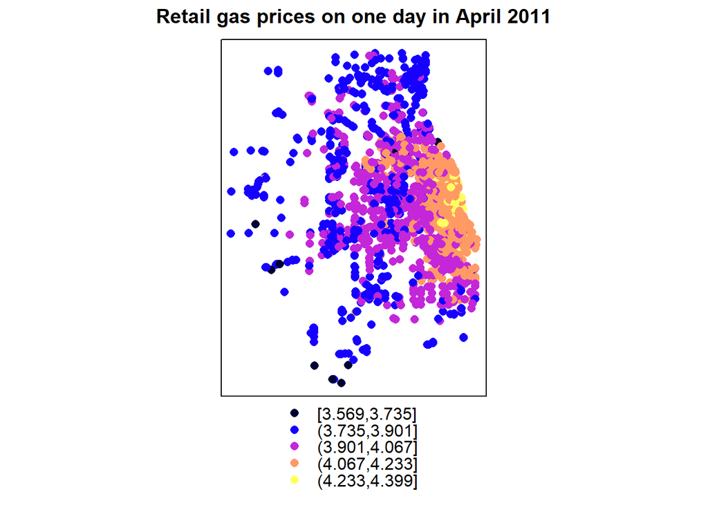

```r
# Assign projection
shapePKt <- spTransform(shapePKT, CRS=CRS("+init=epsg:26971"))

# Plot the example of data in the dataset
spplot(shapePKT, 'Price', main='Retail gas prices on one day in April 2011')
```

## Do you expect the measured values to be spatially correlated?

Yes. The prices closer to the city centre should be higher than the ones ine the suburbs. Prices should lower with the increase of distance from the centre.

## Compute a sample variogram of your dataset, and experiment a bit with the cutoff and width settings

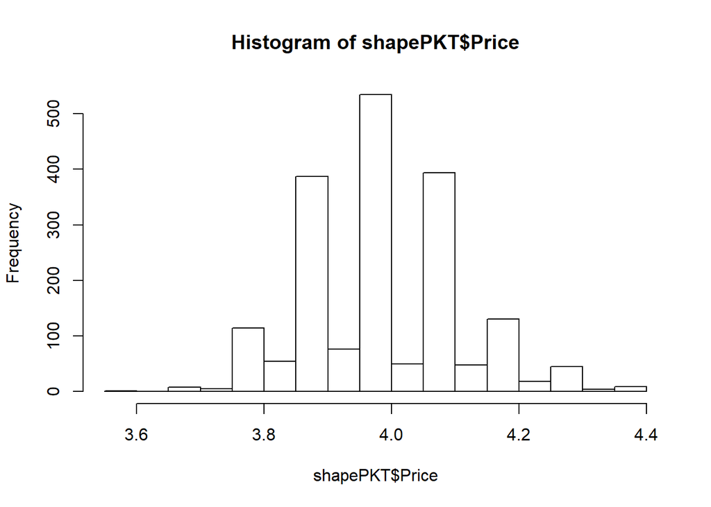

```r
# First compute a histogram
hist(shapePKT$Price)
```

On the histogram we can observe a normal distribution of prices. Most of the stations had prices around 4 $/gallon.

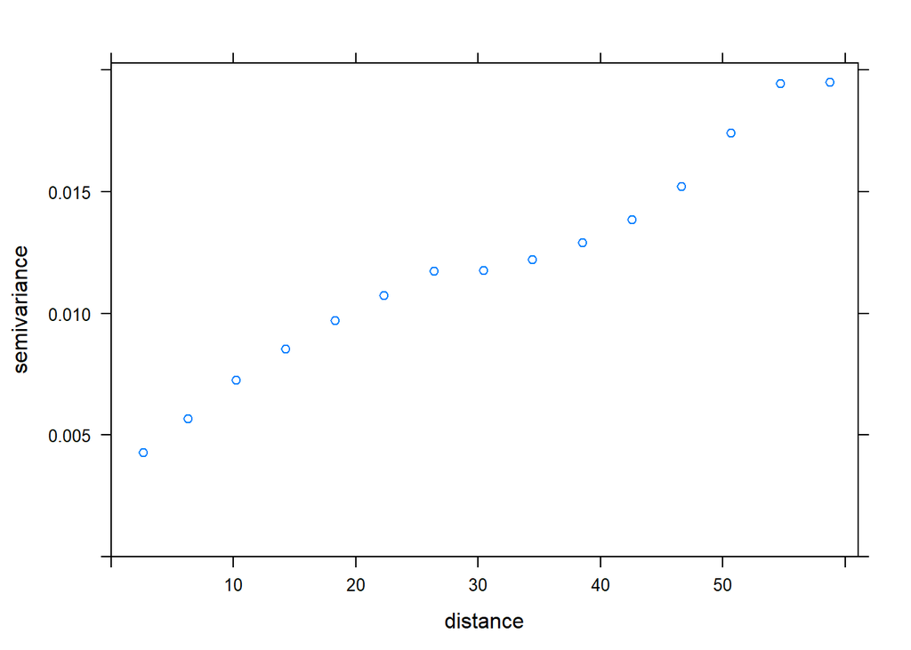

```r
# Plot variogram
plot(variogram(Price~1,data=shapePKT))
```

On the variogram we can observe that the variance of the measured values grows in a stable way till 30 km. Then it stabilize for around 5 km and growes again. To obtain the full picture, the cutoff and width variables were changed for cutoff distance of 200 km and width between the points to 5 km. Moreover, the viarogram is plotted for the N-S direction:

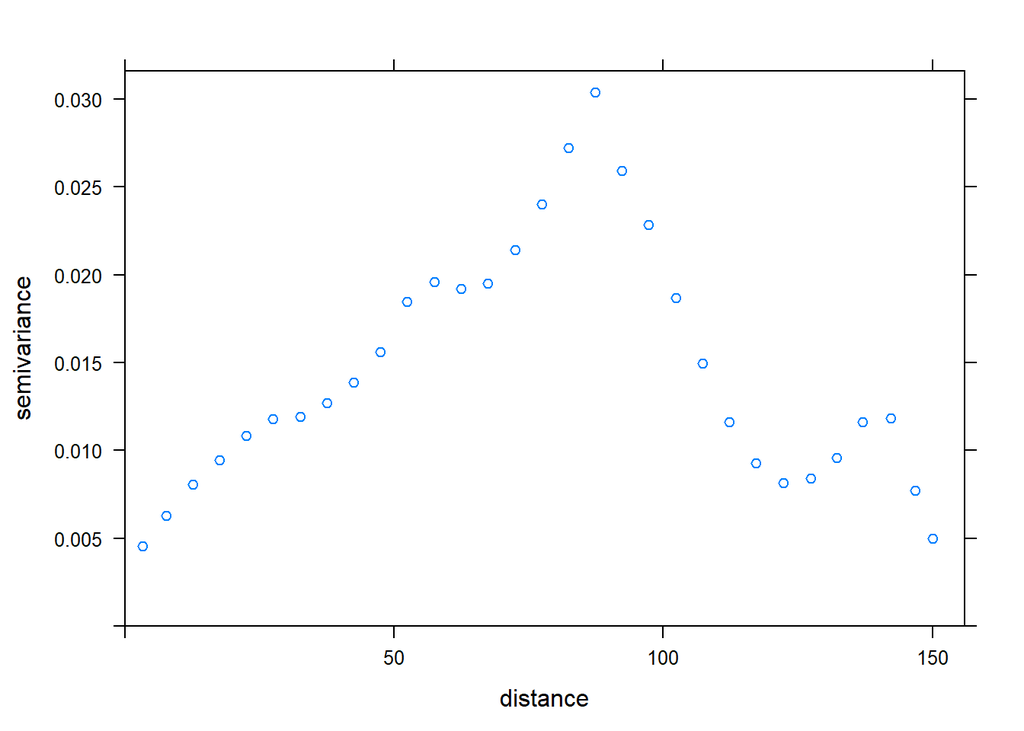

```r
# Plot variogram for B(a)P
plot(variogram(Price~1,data=shapePKT, cutoff=200, width=5, alpha=c(180)))
```

## Fit a variogram model to your sample variogram

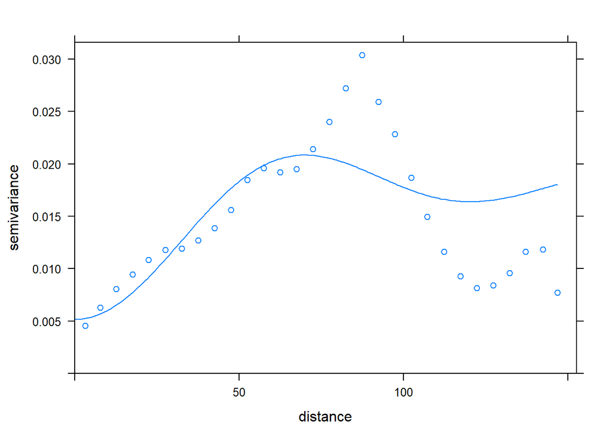

```r
# Fit model
v <- variogram(Price~1,data=shapePKT, cutoff=150, width=5)
f = fit.variogram(v, vgm("Wav"))
plot(v, f)
```

## Describe, in words, the spatial correlation of your variable (is it strong, weak, or absent; does it extend to large distances or only to small)

The spatial correlation of my data is very strong in the distance 0-10 km, strong in the distance 10 - 30 km, moderate in the distance 30-50 km, weak in the distance of 50-75 km and very weak in the distance 75-110 km. Then it grows again and is weak in the distance of around 110-120 km, moderate 120-140 km with stron correlation in the distance of around 125 km and very strong in the distance of around 150 km.